# MNEI de Hu et al. 2007

Danilo Pereira Mori

2022-06-01

### Contexto

Referência Base: Hu, X. S., He, F., & Hubbell, S. P. (2007). Species diversity in local neutral communities. American Naturalist, 170(6), 844–853. https://doi.org/10.1086/522935

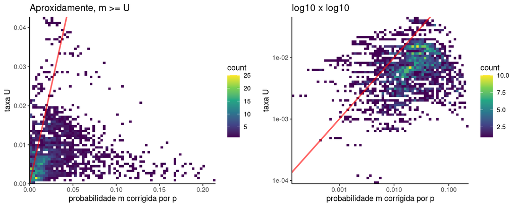

**Figura 1** Probabilidade média de surgimento de um indivíduo de uma nova espécie na paisagem (U) e a probabilidade média de uma colonização na comunidade local ser de um propágulo vindo da paisagem ao redor (m), corrigida pela proporção de cobertura vegetal na paisagem (p).

A maior implicação de m >=U é que não se torna razoável negligenciar U sem negligenciar m.

### Eq. 5, Hu et al. 2007

```r
# equação 5
f_eq5_HUetal2007 <- function(.U,.m,.JL,.JM){
  f_abundance <- function(x, speciation, migration_rate, JL, JM){
    small_theta <- 2*JL*speciation
    capital_theta <- 2*JM*speciation
    migrants <- JL*migration_rate
    f1 <- function(y) (1-y)^(capital_theta-1)/y
    .C <- 1/integrate(f1,1/JM, 1)$value
    c1 <- function(Q){
      lc1 <- lgamma(2*migrants+small_theta+1) -
        (lgamma(2*migrants*(1-Q)+small_theta) + lgamma(2*migrants*Q+1))
      exp(lc1)
    }
    f2 <- function(Q)
      c1(Q)*(1-x)^(2*migrants*(1-Q)+small_theta-1)*x^(2*migrants*Q-1)*(1-Q)^(capital_theta-1)/Q
    .C*integrate(f2, 1/JM, 1)$value
  }
  r.abund <- seq(0.01,0.99, by=0.01) #seq(1/.JL,0.99, by=1/.JL)
  phi.x <- sapply(r.abund, f_abundance , speciation = .U, migration_rate = .m, JL = .JL, JM=.JM)
  df_ <- data.frame(x=r.abund,phi_x=phi.x)
  return(df_)
}
```

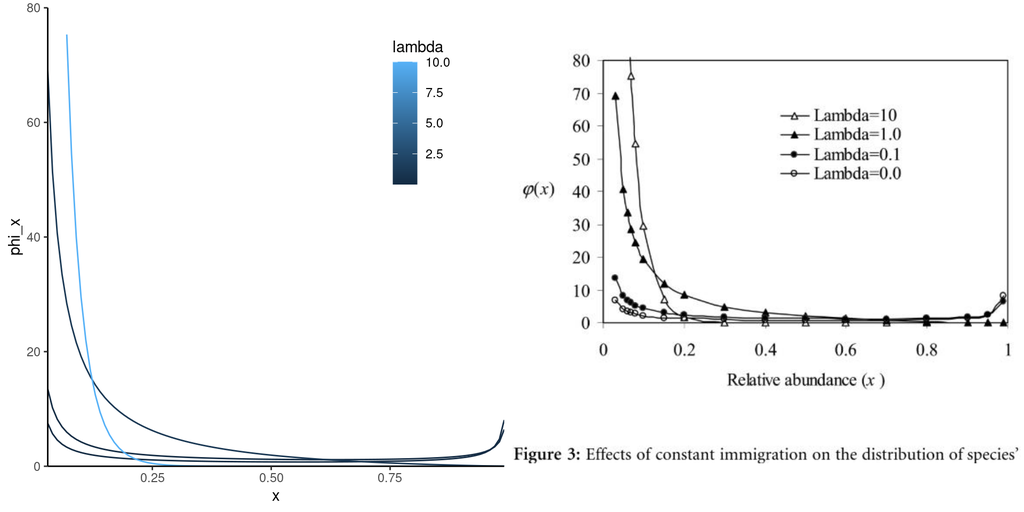

**Figura 2** Comparação da figura 3 de Hu et al. 2007 e aquela obtida pela versão do código em R. Nesse exemplo as abundâncias relativas abaixo de 0.03 não foram adiconados.

##### Uma dúvida:

Como é possível em uma mesma amostra existir mais de uma espécie com abundância relativa de 0.99 ou maior?

### Eq.5 com os parâmetros estimados por MNEE

Por algum motivo há apenas 1032/2060 baterias de simulação. Não entendo o motivo.

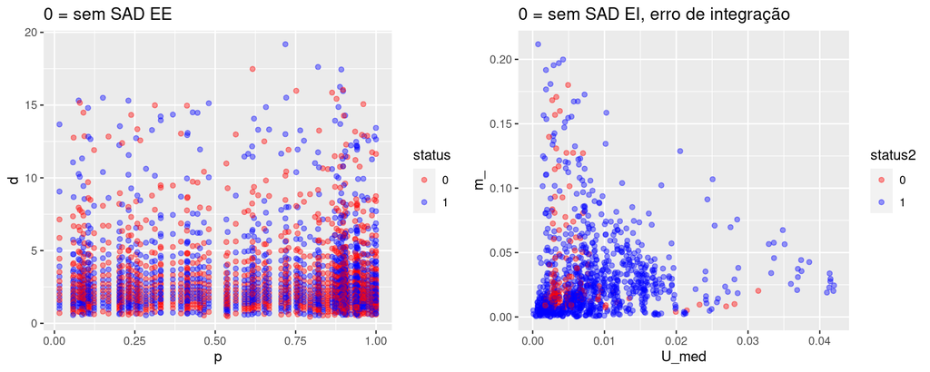

**Figura 3** Painél da esquerda: Sítios e cenários de limitação de dispersão em que está disponível a SAD do modelo espacialmente explícito (SAD EE). Painél da direita: combinação de parâmetros onde o modelo integrou. O erro de integração foi: “Error in integrate(f2, 1/JM, 1) : the integral is probably divergent”.

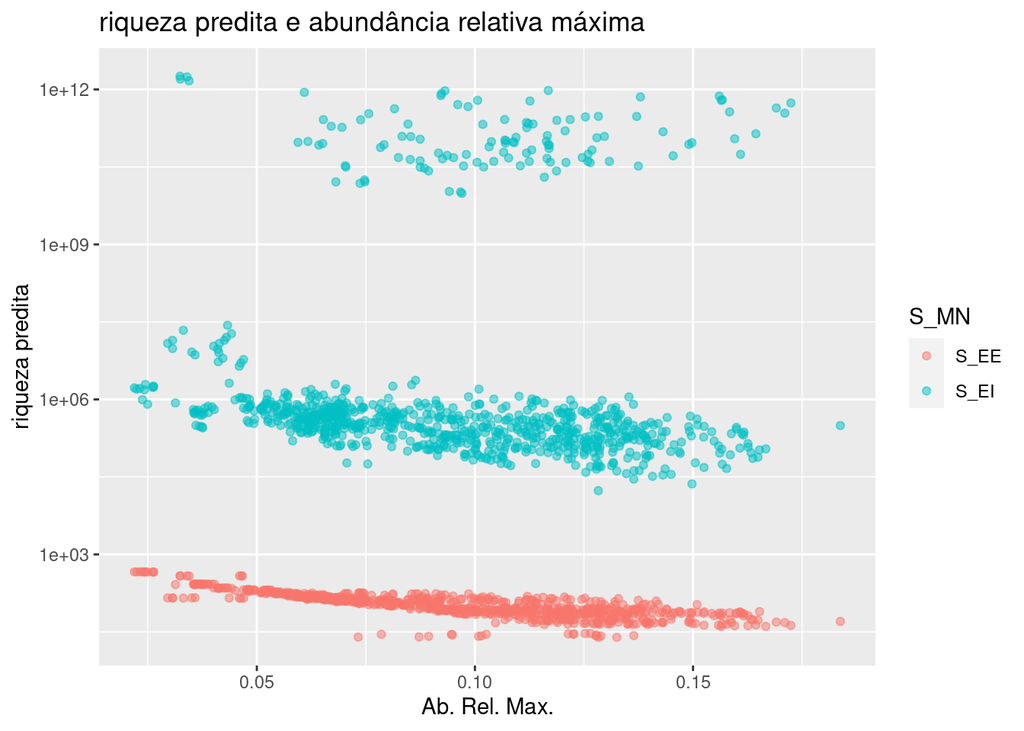

**Figura 4** Riqueza predita pela maior abundância relativa de cada SAD de EE (eixo x). Usamos as classes de abundância relativa simulados por MNEE para calcular o número médio de espécies naquela classe segundo o modelo de Hu et al. 2007. Então somei o número esperado em cada classe (eixo y). As predições do modelo de Hu et al. (2007) são várias ordens de magnitude maiores do que as predições da simulação coalescente, que erra pouco a riqueza observada.